# Xenobiotics modify vertical energy transfer from photoautotrophic biofilms to grazers

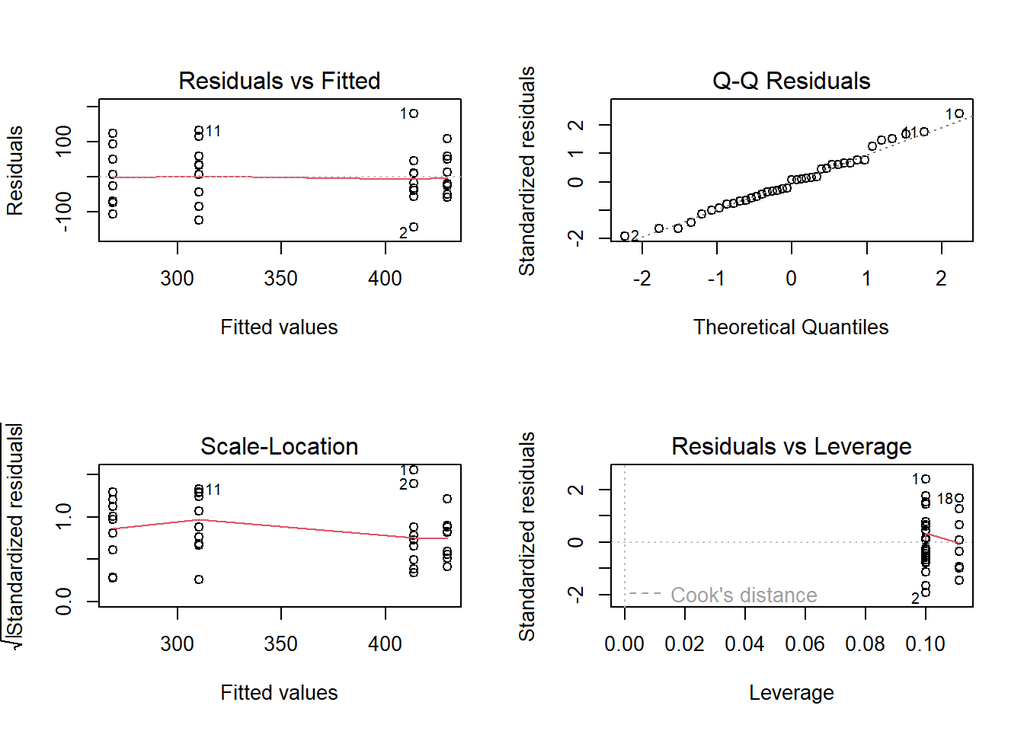

```r
# interaction effect model
model_mix_FA_snails <- lm(sum_FA ~ Cip * Pro, data = total_FA_per_snail)
par(mfrow = c(2, 2))
plot(model_mix_FA_snails)
```

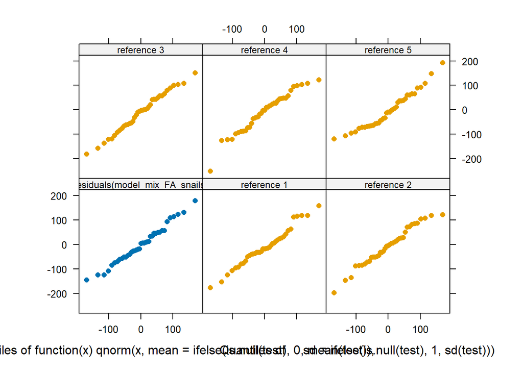

```r
qreference(residuals(model_mix_FA_snails)) # normality acceptable
```

```r
drop1(model_mix_FA_snails, test = 'F')
```

```
Single term deletions

Model:
sum_FA ~ Cip * Pro
        Df Sum of Sq    RSS    AIC F value Pr(>F)
<none>               217883 344.50
Cip:Pro  1    8077.6 225961 343.92  1.2976 0.2624
```

```r
# Cip:Pro interaction not significant

# look deeper into interaction:
# df.ref only control values
df.ref.FA_snails <- total_FA_per_snail |>
  dplyr::filter(Cip == 0, Pro == 0)

# remove grouping
df.ref.FA_snails <- df.ref.FA_snails %>%
  dplyr::ungroup()

nd_FA_snails <- nd.generator(df.ref.FA_snails, stressor1 = "Cip", stressor2 = "Pro", diff = NULL)

#sanity check
table(nd_FA_snails$dataset, nd_FA_snails$Cip)
```

```
       0  1
  C   10  0
  S1   0 10
  S12  0 10
  S2  10  0
```

```r
table(nd_FA_snails$dataset, nd_FA_snails$Pro)
```

```
       0  1
  C   10  0
  S1  10  0
  S12  0 10
  S2   0 10
```

```r
#check for AD, MU (all values >0) and OD
hyp_all_FA_snails <- predictions(
  model_mix_FA_snails,
  newdata = nd_FA_snails,
  hypothesis = function(x) {
    hypothesis.function(
      x,
      stressor1 = "Cip",
      stressor2 = "Pro",
      null = "all",        # <- AD, MU, DO together
      strategy = "average"
    )
  }
) |>
  inferences(method = "simulation")

hyp_all_FA_snails
```

```
 Term Estimate    2.5 % 97.5 %
   ad  -57.626 -154.947 41.527
   do  -41.471 -107.844 30.274
   mu   -0.182   -0.479  0.117

Type: response
```

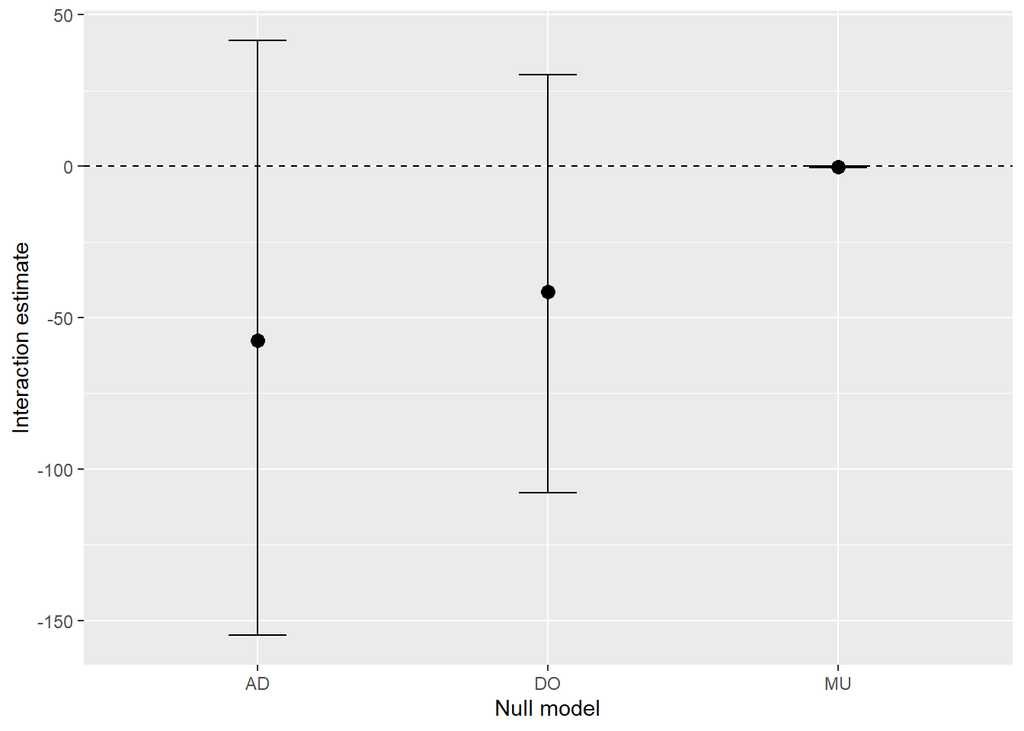

```r
hyp_all_FA_snails$term <- dplyr::recode(hyp_all_FA_snails$term,
                                    "ad" = "AD",
                                    "do" = "DO",
                                    "mu" = "MU")

ggplot(hyp_all_FA_snails, aes(x = term, y = estimate)) +
  geom_point(size = 3) +
  geom_errorbar(aes(ymin = conf.low, ymax = conf.high), width = 0.2) +
  geom_hline(yintercept = 0, linetype = "dashed") +
  labs(x = "Null model", y = "Interaction estimate")
```

Post-estimation inference following Pimentel et al. (2025) indicated that the additive, dominance, and multiplicative null models could not be rejected, as the confidence intervals of the interaction estimates overlapped zero. This suggests that the combined effect of ciprofloxacin and propyzamide did not deviate significantly from expectations based on independent single-stressor effects.

## 7.2 Histogram FA snails

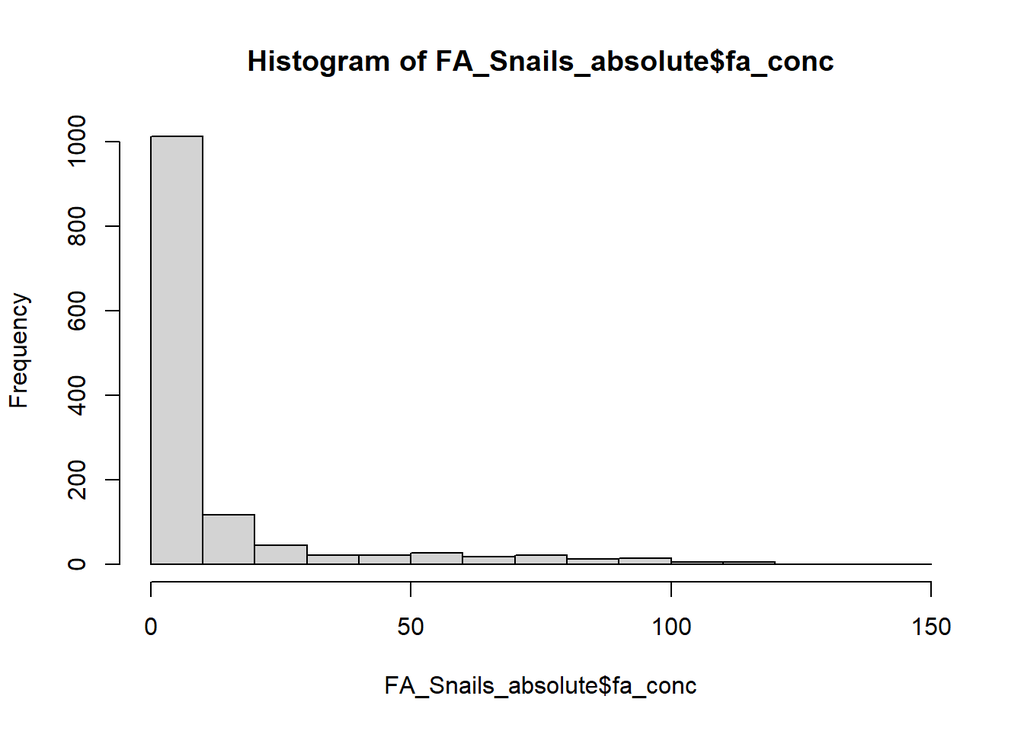

```r
hist(FA_Snails_absolute $ fa_conc)
```

```r
skewness(FA_Snails_absolute $ fa_conc, na.rm = TRUE)
```

```
[1] 2.738149
```

```r
shapiro.test(FA_Snails_absolute $ fa_conc)
```

```
    Shapiro-Wilk normality test

data:  FA_Snails_absolute$fa_conc
W = 0.54871, p-value < 2.2e-16
```

Fatty acid concentration not normal distributed and right skewed.

## 7.3 NMDS FA snails

Change table to wide format:

```r
# change table to wide format (sqrt for square root transformation in next step)
FA_Snails_absolute_wide_sqrt <-
  pivot_wider(FA_Snails_absolute,
              names_from = fa,
              values_from = fa_conc)

# square root transformation, to reduce discriminatory power of dominant FA groups
FA_Snails_absolute_wide_sqrt[, 3:36] <- sqrt(FA_Snails_absolute_wide_sqrt[, 3:36])

# Only keep columns/FAs with more than 5 non-zero values (fatty acids that have just been found in 5 replicates will be removed)
FA_Snails_absolute_wide_sqrt <-
  FA_Snails_absolute_wide_sqrt %>%
  dplyr::select(
    1:2,
    where(~sum(. !=0, na.rm = TRUE)>5)
  )
```

Perform metaMDS:

```r
# Remove first and second column for metaMDS
FA_Snails_absolute_wide_sqrt <- FA_Snails_absolute_wide_sqrt[, -c(1, 2)]

# Rename (- C, - () ) fatty acids for later plot
FA_Snails_absolute_wide_sqrt <- FA_Snails_absolute_wide_sqrt %>%
  rename(
    `12:0`     = `C12:0`,
    `13:0`     = `C13:0`,
    `14:0`     = `C14:0`,
    `15:0`     = `C15:0`,
    `16:0`     = `C16:0`,
    `16:1`     = `C16:1`,
    `18:0`     = `C18:0`,
    `18:1`     = `C18:1`,
    `18:2n-6c` = `C18:2(n-6c)`,
    `18:3n-6`  = `C18:3(n-6)`,
    `18:3n-3`  = `C18:3(n-3)`,
    `18:4n-3`  = `C18:4(n-3)`,
    `20:0`     = `C20:0`,
    `20:1`     = `C20:1`,
    `20:2n-6`  = `C20:2(n-6)`,
    `20:3n-6`  = `C20:3(n-6)`,
    `20:4n-6`  = `C20:4(n-6)`,
    `20:5n-3`  = `C20:5(n-3)`,
    `22:1`     = `C22:1`,
    `22:5n-3`  = `C22:5(n-3)`,
    `22:6n-3`  = `C22:6(n-3)`
)


NMDS_Snails_absolute <-
  metaMDS(
    FA_Snails_absolute_wide_sqrt,
    autotransform = FALSE,
    k = 2 ,
    distance = "bray",
    na.rm = TRUE
  )
```

```
*** Best solution repeated 1 times
```

```r
NMDS_Snails_absolute$stress
```

```
[1] 0.1089254
```

Create fa vectors:

```r
# separation in SAFA; MUFA & PUFA to build vectors in NMDS
# "sa" = snail absolute
FA_variables.SAFAs_sa <-
  envfit(
    NMDS_Snails_absolute,
    subset(
      FA_Snails_absolute_wide_sqrt,
      select = c(
        "12:0",
        "13:0",
        "14:0",
        "15:0",
        "16:0",
        "18:0",
        "20:0"
      )
    )
    ,
    permutations = 999,
    na.rm = TRUE
  )

FA_variables.MUFAs_sa <-
  envfit(
    NMDS_Snails_absolute,
    subset(
      FA_Snails_absolute_wide_sqrt,
      select = c(
        "16:1",
        "18:1",
        "20:1",
        "22:1"
      )
    )
    ,
    permutations = 999,
    na.rm = TRUE
  )

FA_variables.PUFAs_sa <-
  envfit(
    NMDS_Snails_absolute,
    subset(
      FA_Snails_absolute_wide_sqrt,
      select = c(
        "18:2n-6c",
        "18:3n-6",
        "18:3n-3",
        "18:4n-3",
        "20:2n-6",
        "20:3n-6",
        "20:4n-6",
        "20:5n-3",
        "22:5n-3",
        "22:6n-3"
      )
    )
    ,
    permutations = 999,
    na.rm = TRUE
  )

# Extract NMDS scores
data.scores_snail_absolute = as.data.frame(scores(NMDS_Snails_absolute)$sites)

Treatments <-
  FA_Snails_absolute $ treatment[FA_Snails_absolute $ fa == "C16:0"]

# add treatment column to NMDS scores
data.scores_snail_absolute$Treatment = Treatments

# vectors for SAFA, MUFA and PUFA
SAFAs_coord_cont_sa = as.data.frame(scores(FA_variables.SAFAs_sa, "vectors")) * ordiArrowMul(FA_variables.SAFAs_sa)
MUFAs_coord_cont_sa = as.data.frame(scores(FA_variables.MUFAs_sa, "vectors")) * ordiArrowMul(FA_variables.MUFAs_sa)
PUFAs_coord_cont_sa = as.data.frame(scores(FA_variables.PUFAs_sa, "vectors")) * ordiArrowMul(FA_variables.PUFAs_sa)
```

Plot NMDS:

[figure not shown]

```r
# For the plot: reorder treatment variable in data.scores_snail_absolute
data.scores_snail_absolute$Treatment <- factor(
  data.scores_snail_absolute$Treatment,
  levels = c("NC", "Pro", "Cip", "Mix"),
  labels  = c("Control", "Propyzamide", "Ciprofloxacin", "Mixture")
)

# Compute convex hull for each Treatment
polygon_data_snails <- data.scores_snail_absolute %>%
  group_by(Treatment) %>%
  summarise(hull_points = list(data.frame(
    NMDS1 = NMDS1[chull(NMDS1, NMDS2)],
    NMDS2 = NMDS2[chull(NMDS1, NMDS2)]
  ))) %>%
  unnest(hull_points)

# Function to rescale coordinates
rescale_vectors <- function(df, scale_factor = 1) {
  df$length <- sqrt(df$NMDS1^2 + df$NMDS2^2)
  max_length <- max(df$length)
  df$NMDS1 <- df$NMDS1 / max_length * scale_factor
  df$NMDS2 <- df$NMDS2 / max_length * scale_factor
  df$length <- NULL
  return(df)
}

# Apply to each group
PUFAs_coord_cont_sa <- rescale_vectors(PUFAs_coord_cont_sa, 0.4)
MUFAs_coord_cont_sa <- rescale_vectors(MUFAs_coord_cont_sa, 0.4)
SAFAs_coord_cont_sa <- rescale_vectors(SAFAs_coord_cont_sa, 0.4)

# plot
absol_snail_with_vectors <- ggplot(data = data.scores_snail_absolute, aes(x = NMDS1, y = NMDS2)) +
    geom_polygon(
    data = polygon_data_snails,
    aes(x = NMDS1, y = NMDS2, group = Treatment, fill = Treatment),
    alpha = 0.2,
    show.legend = FALSE
    ) +
  geom_point(
    aes(shape = Treatment, color = Treatment),
    size = 5,
    alpha = 1,
    show.legend = TRUE
  ) +
  scale_shape_manual(values = c("Control" = 16, "Propyzamide" = 17, "Ciprofloxacin" = 18, "Mixture" = 15)) +
  scale_color_manual(values = c("Control" = "#009E73", "Propyzamide" = "#E69F00", "Ciprofloxacin" = "#56B4E9", "Mixture" = "#999999")) +
  scale_fill_manual(values = c("Control" = "#009E73", "Propyzamide" = "#E69F00", "Ciprofloxacin" = "#56B4E9", "Mixture" = "#999999")) +
  geom_segment(aes(x = 0, y = 0, xend = NMDS1, yend = NMDS2),
               data = PUFAs_coord_cont_sa, linewidth = 0.5, alpha = 0.2, colour = "black") +
  geom_segment(aes(x = 0, y = 0, xend = NMDS1, yend = NMDS2),
               data = MUFAs_coord_cont_sa, linewidth = 0.5, alpha = 0.2, colour = "black") +
  geom_segment(aes(x = 0, y = 0, xend = NMDS1, yend = NMDS2),
               data = SAFAs_coord_cont_sa, linewidth = 0.5, alpha = 0.2, colour = "black") +
  geom_text_repel(
    data = PUFAs_coord_cont_sa,
    aes(x = NMDS1, y = NMDS2, label = row.names(PUFAs_coord_cont_sa)),
    colour = "black",
    size = 2.5) +
  geom_text_repel(
    data = MUFAs_coord_cont_sa,
    aes(x = NMDS1, y = NMDS2, label = row.names(MUFAs_coord_cont_sa)),
    colour = "#996600",
    size = 2.5) +
  geom_text_repel(
    data = SAFAs_coord_cont_sa,
    aes(x = NMDS1, y = NMDS2, label = row.names(SAFAs_coord_cont_sa)),
    colour = "#0000FF",
    size = 2.5) +
  theme_bw() +
  theme(
    axis.title = element_text(
      size = 13,
      face = "bold",
      colour = "grey30"
    ),
    panel.background = element_blank(),
    panel.border = element_rect(fill = NA, colour = "grey30"),
    legend.key = element_blank(),
    legend.title = element_text(
      size = 11,
      face = "bold",
      colour = "grey30"
    ),
    legend.text = element_text(size = 10, colour = "grey30"),
    panel.grid.major = element_line(colour = "grey95", size = 0.4),
    panel.grid.minor = element_line(colour = "grey95", size = 0.2)
  )

absol_snail_with_vectors
```

```r
# position of FA names were manually adjusted for publication in vector graphic in the software Inkscape
```

Save the plot as .png:

```r
ggsave(
  "output/NMDS_snails_absolute_vectors.png",
  width = 16.5,
  height = 12,
  units = "cm",
  dpi = 600
)
```

Save the plot as vector graphic (minor adaptions for better readability with Inkscape):

```r
ggsave(
  "output/NMDS_snails_absolute_vectors.svg",
  device = "svg",
  width = 16.5,
  height = 16,
  units = "cm",
  dpi = 600
)
```

Now plot NMDS without fatty acid vectors:

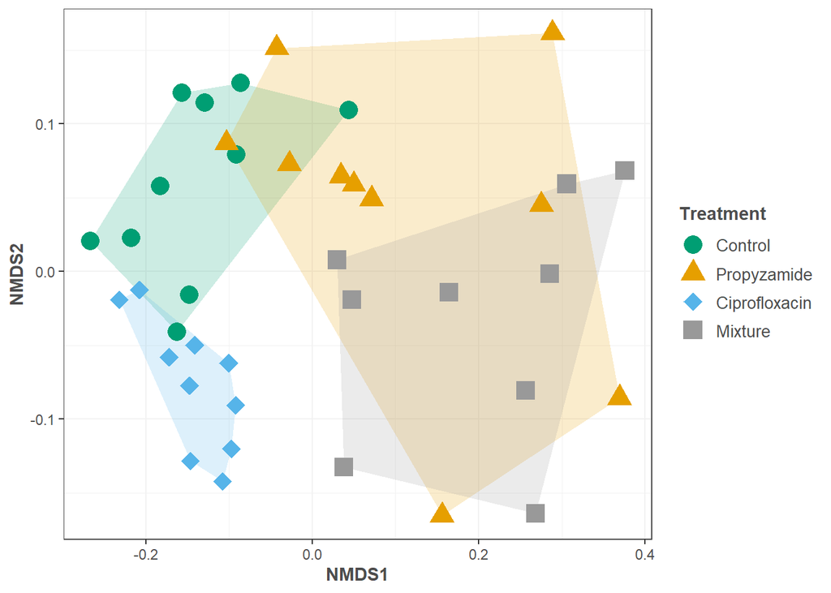

```r
# plot
absol_snail <- ggplot(data = data.scores_snail_absolute, aes(x = NMDS1, y = NMDS2)) +
    geom_polygon(
    data = polygon_data_snails,
    aes(x = NMDS1, y = NMDS2, group = Treatment, fill = Treatment),
    alpha = 0.2,
    show.legend = FALSE
  ) +
  geom_point(
    aes(shape = Treatment, color = Treatment),
    size = 5,
    alpha = 1,
    show.legend = TRUE
  ) +
  scale_shape_manual(values = c("Control" = 16, "Propyzamide" = 17, "Ciprofloxacin" = 18, "Mixture" = 15)) +
  scale_color_manual(values = c("Control" = "#009E73", "Propyzamide" = "#E69F00", "Ciprofloxacin" = "#56B4E9", "Mixture" = "#999999")) +
  scale_color_manual(values = c("Control" = "#009E73", "Propyzamide" = "#E69F00", "Ciprofloxacin" = "#56B4E9", "Mixture" = "#999999")) +
  scale_fill_manual(values = c("Control" = "#009E73", "Propyzamide" = "#E69F00", "Ciprofloxacin" = "#56B4E9", "Mixture" = "#999999")) +
  theme_bw() +
  theme(
    axis.title = element_text(
      size = 11,
      face = "bold",
      colour = "grey30"
    ),
    panel.background = element_blank(),
    panel.border = element_rect(fill = NA, colour = "grey30"),
    legend.key = element_blank(),
    legend.title = element_text(
      size = 11,
      face = "bold",
      colour = "grey30"
    ),
    legend.text = element_text(size = 10, colour = "grey30"),
    panel.grid.major = element_line(colour = "grey95", size = 0.4),
    panel.grid.minor = element_line(colour = "grey95", size = 0.2)
  )
absol_snail
```

Save the plot as .png:

```r
ggsave(
  "output/NMDS_snails_absolute.png",
  width = 16.5,
  height = 12,
  units = "cm",
  dpi = 600
)
```

Save the plot as vector graphic:

```r
ggsave(
  "output/NMDS_snails_absolute.svg",
  device = "svg",
  width = 16.5,
  height = 16,
  units = "cm",
  dpi = 600
)
```

## 7.4 PERMANOVA FA snails

Create distance matrix with fatty acids:

```r
FA_Snails_dist <- vegdist(FA_Snails_absolute_wide_sqrt, method = 'bray')
```

Separate explanatory variables from fatty acid information:

```r
# change initial table to wide format again
FA_Snails_absolute_wide_permanova <-
  pivot_wider(FA_Snails_absolute,
              names_from = fa,
              values_from = fa_conc)

# square root transformation again, to reduce discriminatory power of dominant fa groups
FA_Snails_absolute_wide_permanova[, 3:28] <- sqrt(FA_Snails_absolute_wide_permanova[, 3:28])

# Only keep columns/FAs with more than 5 non-zero values (fatty acids that have just been found in 5 replicates will be removed)
FA_Snails_absolute_wide_permanova <-
  FA_Snails_absolute_wide_permanova %>%
  dplyr::select(
    1:2,
    where(~sum(. !=0, na.rm = TRUE)>5)
  )

# delete fa columns
FA_Snails_absolute_wide_permanova <- FA_Snails_absolute_wide_permanova[, c(1, 2)]
FA_Snails_absolute_wide_permanova $ treatment <- as.factor(FA_Snails_absolute_wide_permanova $ treatment)
```

Perform PERMANOVA:

```r
perm_FA_Snails <- adonis2(FA_Snails_dist ~ treatment, data = FA_Snails_absolute_wide_permanova, permutations = 999)
print(perm_FA_Snails)
```

```
Permutation test for adonis under reduced model
Terms added sequentially (first to last)
Permutation: free
Number of permutations: 999

adonis2(formula = FA_Snails_dist ~ treatment, data = FA_Snails_absolute_wide_permanova, permutations = 999)
          Df SumOfSqs      R2      F Pr(>F)
treatment  3  0.34282 0.50206 11.763  0.001 ***
Residual  35  0.34001 0.49794
Total     38  0.68283 1.00000
---
Signif. codes:  0 '***' 0.001 '**' 0.01 '*' 0.05 '.' 0.1 ' ' 1
```

Pairwise comparisons (by: Martinez Arbizu, P. (2020). pairwiseAdonis: Pairwise multilevel comparison using adonis. R package version 0.4):

```r
pairwise_results <- pairwise.adonis2(
  FA_Snails_dist ~ treatment,
  data = FA_Snails_absolute_wide_permanova,
  permutations = 999
)

# View the results
print(pairwise_results)
```

```
$parent_call
[1] "FA_Snails_dist ~ treatment , strata = Null , permutations 999"

$NC_vs_Pro
          Df SumOfSqs      R2      F Pr(>F)
treatment  1  0.10971 0.35642 9.9684  0.001 ***
Residual  18  0.19811 0.64358
Total     19  0.30782 1.00000
---
Signif. codes:  0 '***' 0.001 '**' 0.01 '*' 0.05 '.' 0.1 ' ' 1

$NC_vs_Mix
          Df SumOfSqs      R2     F Pr(>F)
treatment  1  0.18442 0.52422 18.73  0.001 ***
Residual  17  0.16738 0.47578
Total     18  0.35180 1.00000
---
Signif. codes:  0 '***' 0.001 '**' 0.01 '*' 0.05 '.' 0.1 ' ' 1

$NC_vs_Cip
          Df SumOfSqs      R2      F Pr(>F)
treatment  1 0.046091 0.32447 8.6456  0.001 ***
Residual  18 0.095962 0.67553
Total     19 0.142053 1.00000
---
Signif. codes:  0 '***' 0.001 '**' 0.01 '*' 0.05 '.' 0.1 ' ' 1

$Pro_vs_Mix
          Df SumOfSqs      R2      F Pr(>F)
treatment  1 0.026685 0.09856 1.8588  0.122
Residual  17 0.244050 0.90144
Total     18 0.270735 1.00000

$Pro_vs_Cip
          Df SumOfSqs      R2      F Pr(>F)
treatment  1  0.14011 0.44801 14.609  0.001 ***
Residual  18  0.17263 0.55199
Total     19  0.31274 1.00000
---
Signif. codes:  0 '***' 0.001 '**' 0.01 '*' 0.05 '.' 0.1 ' ' 1

$Mix_vs_Cip
          Df SumOfSqs      R2      F Pr(>F)
treatment  1  0.18109 0.56066 21.694  0.001 ***
Residual  17  0.14190 0.43934
Total     18  0.32299 1.00000
---
Signif. codes:  0 '***' 0.001 '**' 0.01 '*' 0.05 '.' 0.1 ' ' 1

attr(,"class")
[1] "pwadstrata" "list"
```

```r
# Cip*Pro interaction?
# add presence / absence columns
FA_Snails_absolute_wide_permanova$Cip <- ifelse(FA_Snails_absolute_wide_permanova$treatment %in% c("Cip", "Mix"),
                                                 1,
                                                 0)

FA_Snails_absolute_wide_permanova$Cip <-
  factor(FA_Snails_absolute_wide_permanova$Cip, levels = c(0, 1))

FA_Snails_absolute_wide_permanova$Pro <- ifelse(FA_Snails_absolute_wide_permanova$treatment %in% c("Pro", "Mix"),
                                                 1,
                                                 0)

FA_Snails_absolute_wide_permanova$Pro <-
  factor(FA_Snails_absolute_wide_permanova$Pro, levels = c(0, 1))

# sanity check
table(FA_Snails_absolute_wide_permanova$treatment,
      FA_Snails_absolute_wide_permanova$Cip)
```

```
       0  1
  Cip  0 10
  Mix  0  9
  NC  10  0
  Pro 10  0
```

```r
table(FA_Snails_absolute_wide_permanova$treatment,
      FA_Snails_absolute_wide_permanova$Pro)
```

```
       0  1
  Cip 10  0
  Mix  0  9
  NC  10  0
  Pro  0 10
```

```r
# permanova
perm_FA_snails_Cip_Pro <- adonis2(FA_Snails_dist ~ Cip * Pro,
        data = FA_Snails_absolute_wide_permanova,
        permutations = 999)

print(perm_FA_snails_Cip_Pro)
```

```
Permutation test for adonis under reduced model
Terms added sequentially (first to last)
Permutation: free
Number of permutations: 999

adonis2(formula = FA_Snails_dist ~ Cip * Pro, data = FA_Snails_absolute_wide_permanova, permutations = 999)
         Df SumOfSqs      R2       F Pr(>F)
Cip       1  0.05202 0.07618  5.3548  0.007 **
Pro       1  0.27117 0.39713 27.9140  0.001 ***
Cip:Pro   1  0.01963 0.02874  2.0202  0.093 .
Residual 35  0.34001 0.49794
Total    38  0.68283 1.00000
---
Signif. codes:  0 '***' 0.001 '**' 0.01 '*' 0.05 '.' 0.1 ' ' 1
```

```r
# no interaction
```

All treatments except of Pro_vs_Mix significant differences. No Cip * Pro interaction.

## 7.5 SIMPER FA snails

```r
# Perform SIMPER
simper_FA_Snails <-
  with(
    FA_Snails_absolute_wide_permanova,
    simper(FA_Snails_absolute_wide_sqrt, treatment,  permutations = 999)
  )

summary(simper_FA_Snails)
```

```
Contrast: NC_Pro

          average       sd    ratio      ava      avb cumsum     p
18:1     0.023053 0.022383 1.030000 8.688000 6.533000  0.122 0.207
14:0     0.021510 0.009257 2.323700 3.546000 0.808000  0.235 0.007 **
16:1     0.018416 0.013910 1.323900 7.403000 5.444000  0.332 0.301
13:0     0.014510 0.014806 0.980000 1.953000 0.000000  0.409 0.677
16:0     0.011839 0.008579 1.380000 9.491000 8.564000  0.471 0.534
18:2n-6c 0.011586 0.010710 1.081700 5.728000 4.426000  0.532 0.603
15:0     0.010445 0.004475 2.334300 1.616000 0.281000  0.587 0.001 ***
18:4n-3  0.007891 0.005284 1.493400 1.147000 0.315000  0.629 0.003 **
18:3n-3  0.007214 0.007175 1.005400 2.981000 2.134000  0.667 0.161
22:1     0.007209 0.004617 1.561300 2.920000 3.774000  0.705 0.450
20:5n-3  0.006962 0.004547 1.531200 4.511000 3.791000  0.742 0.120
18:0     0.006887 0.005905 1.166300 7.291000 7.638000  0.778 0.835
20:2n-6  0.005894 0.006049 0.974400 2.632000 2.123000  0.809 0.238
12:0     0.005657 0.005761 0.981900 0.758000 0.000000  0.839 0.526
20:1     0.005505 0.005766 0.954800 2.368000 2.713000  0.868 0.646
18:3n-6  0.005171 0.003735 1.384400 1.365000 0.774000  0.895 0.845
20:4n-6  0.004639 0.003405 1.362500 3.827000 3.616000  0.920 0.779
20:0     0.004552 0.003891 1.169600 1.229000 0.998000  0.944 0.234
20:3n-6  0.004519 0.003314 1.363500 1.133000 0.693000  0.968 0.832
22:5n-3  0.003636 0.003612 1.006900 1.715000 1.677000  0.987 0.424
22:6n-3  0.002505 0.001694 1.478300 1.191000 0.984000  1.000 0.799
---
Signif. codes:  0 '***' 0.001 '**' 0.01 '*' 0.05 '.' 0.1 ' ' 1

Contrast: NC_Mix

          average       sd    ratio      ava      avb cumsum     p
14:0     0.027128 0.007289 3.722000 3.546000 0.627000  0.118 0.001 ***
18:1     0.026138 0.013381 1.953000 8.688000 5.502000  0.232 0.038 *
16:1     0.024249 0.015982 1.517000 7.403000 4.528000  0.337 0.005 **
18:2n-6c 0.019180 0.013189 1.454000 5.728000 3.414000  0.420 0.002 **
13:0     0.015114 0.015406 0.981000 1.953000 0.000000  0.486 0.540
16:0     0.012800 0.010003 1.280000 9.491000 8.524000  0.542 0.301
15:0     0.009977 0.003990 2.500000 1.616000 0.367000  0.585 0.002 **
18:3n-6  0.009466 0.003552 2.665000 1.365000 0.196000  0.626 0.001 ***
18:3n-3  0.009183 0.004527 2.029000 2.981000 1.847000  0.666 0.003 **
22:1     0.008745 0.005024 1.741000 2.920000 4.001000  0.704 0.015 *
```

[output cut: 108 more lines]

```
20:4n-6   0.006620  0.007047  0.940000  3.668000  3.325000  0.802 0.253
22:1      0.006340  0.004761  1.332000  4.001000  4.660000  0.831 0.869
20:5n-3   0.006150  0.004426  1.390000  3.591000  4.035000  0.858 0.530
18:4n-3   0.005910  0.004370  1.353000  0.178000  0.804000  0.885 0.365
18:3n-3   0.005630  0.003854  1.462000  1.847000  2.504000  0.910 0.589
18:3n-6   0.003680  0.004222  0.872000  0.196000  0.415000  0.927 1.000
22:5n-3   0.003520  0.003808  0.925000  1.594000  1.505000  0.943 0.522
20:2n-6   0.003500  0.003059  1.143000  1.861000  2.167000  0.958 0.933
22:6n-3   0.003250  0.002673  1.215000  0.898000  0.832000  0.973 0.212
20:0      0.003170  0.003438  0.923000  1.184000  1.090000  0.987 0.853
20:3n-6   0.002910  0.003551  0.821000  0.265000  0.205000  1.000 1.000
---
Signif. codes:  0 '***' 0.001 '**' 0.01 '*' 0.05 '.' 0.1 ' ' 1
Permutation: free
Number of permutations: 999
```

```r
str(simper_FA_Snails)
```

[output not shown]

[output cut: 85 more lines]

[output not shown]

```r
# save tsv tables of FAs which contribute > 70% to differences
simper_sum_snails <- summary(simper_FA_Snails)

out_dir <- "output"
dir.create(out_dir, showWarnings = FALSE)

# Safe filename helper
safe_name <- function(x) gsub("[^A-Za-z0-9_]+", "_", x)

iwalk(simper_sum_snails, function(x, nm) {
  if (is.null(x)) return(invisible(NULL))

  # SIMPER summary as a data.frame:
  # columns: average, sd, ratio, ava, avb, cumsum, p
  # rownames are the fatty acid IDs
  df <- as.data.frame(x)

  # keep rows up to the first that reaches/exceeds 70%
  idx <- which(df$cumsum >= 0.70)[1]
  if (is.na(idx)) idx <- nrow(df)
  out <- df[seq_len(idx), , drop = FALSE]

  # just keep 3 decimels
  out_write <- out
  num_cols <- vapply(out_write, is.numeric, logical(1))
  out_write[, num_cols] <- lapply(out_write[, num_cols, drop = FALSE],
                                  function(col) formatC(col, format = "f", digits = 3))

  file <- file.path(out_dir, paste0(safe_name(nm), "_top70_snails.tsv"))
  # write row names so the TSV mirrors the SIMPER structure
  write.table(out_write, file, sep = "\t", quote = FALSE, col.names = NA)
})

# Combine results into a data frame
simper_results_snails <- do.call(rbind, lapply(simper_FA_Snails, function(x) {
  if (!is.null(x$p)) {
    data.frame(
      fatty_acid = names(x$p),
      p = as.numeric(x$p),
      average = as.numeric(x$average),
      sd = as.numeric(x$sd),
      ratio = as.numeric(x$ratio),
      cusum = as.numeric(x$cusum),
      stringsAsFactors = FALSE
    )
  } else {
    NULL
  }
}))

# Show only significant results
simper_results_snails %>%
  dplyr::filter(p <= 0.05) %>%
  dplyr::select(fatty_acid, p, average, sd, ratio, cusum)
```

```
           fatty_acid     p     average          sd    ratio     cusum
NC_Pro.3         14:0 0.007 0.021509958 0.009256829 2.323685 0.3321699
NC_Pro.4         15:0 0.001 0.010444932 0.004474542 2.334302 0.4086985
NC_Pro.12     18:4n-3 0.003 0.007891124 0.005283949 1.493414 0.7780702
NC_Mix.3         14:0 0.001 0.027127502 0.007289395 3.721502 0.3371043
NC_Mix.4         15:0 0.002 0.009976571 0.003990180 2.500281 0.4205162
NC_Mix.6         16:1 0.005 0.024249214 0.015982038 1.517279 0.5419093
NC_Mix.8         18:1 0.038 0.026138364 0.013380824 1.953420 0.6264644
NC_Mix.9     18:2n-6c 0.002 0.019180035 0.013188887 1.454257 0.6663990
NC_Mix.10     18:3n-6 0.001 0.009466359 0.003552305 2.664850 0.7044300
NC_Mix.11     18:3n-3 0.003 0.009182727 0.004526689 2.028575 0.7408099
NC_Mix.12     18:4n-3 0.003 0.008365338 0.005056483 1.654379 0.7770081
NC_Mix.14        20:1 0.003 0.008132913 0.004845627 1.678403 0.8473091
NC_Mix.16     20:3n-6 0.001 0.007169849 0.003547604 2.021040 0.9076795
NC_Mix.18     20:5n-3 0.005 0.008032385 0.004748966 1.691396 0.9541758
NC_Mix.19        22:1 0.015 0.008744995 0.005024025 1.740635 0.9711379
NC_Cip.10     18:3n-6 0.006 0.006932240 0.003427148 2.022743 0.6401295
NC_Cip.16     20:3n-6 0.002 0.006599529 0.003078539 2.143721 0.8703451
NC_Cip.19        22:1 0.001 0.011903292 0.003746862 3.176870 0.9589726
Pro_Mix.6        16:1 0.033 0.021458003 0.014887881 1.441307 0.5982294
Pro_Mix.8        18:1 0.001 0.030520489 0.015135727 2.016453 0.6879517
Pro_Mix.9    18:2n-6c 0.011 0.016720843 0.012909315 1.295254 0.7257353
Pro_Mix.14       20:1 0.002 0.009153328 0.004803422 1.905585 0.8956701
Pro_Cip.1        12:0 0.001 0.010245092 0.004100779 2.498328 0.1499015
Pro_Cip.2        13:0 0.001 0.030661785 0.003598076 8.521716 0.2694924
Pro_Cip.3        14:0 0.002 0.024461877 0.008442459 2.897482 0.3785550
Pro_Cip.4        15:0 0.001 0.011775793 0.004685142 2.513434 0.4546430
Mix_Cip.1        12:0 0.001 0.010678981 0.004242691 2.517030 0.1433818
Mix_Cip.2        13:0 0.001 0.031976418 0.003491965 9.157140 0.2768987
Mix_Cip.3        14:0 0.001 0.029776378 0.006578516 4.526306 0.3832774
Mix_Cip.4        15:0 0.001 0.011526558 0.003800266 3.033092 0.4726897
Mix_Cip.5        16:0 0.041 0.014781711 0.011180620 1.322083 0.5397306
```

```r
# How often do they occur
simper_results_snails %>%
  dplyr::filter(p <= 0.05) %>%
  dplyr::count(fatty_acid) %>%
  dplyr::arrange(desc(n)) %>%
  print()
```

```
   fatty_acid n
1        14:0 4
2        15:0 4
3        12:0 2
4        13:0 2
5        16:1 2
6        18:1 2
7    18:2n-6c 2
8     18:3n-6 2
9     18:4n-3 2
10       20:1 2
11    20:3n-6 2
12       22:1 2
13       16:0 1
14    18:3n-3 1
15    20:5n-3 1
```

# 8 Temperature and light conditions

## 8.1 Biofilm colonisation and contamination

```r
# insert data
colonisation_temp_light <-
  read.table(file.path("data\\colonisation_temp_light.txt"),
             header = TRUE, sep = "\t")

View(colonisation_temp_light)

# average temperature
mean(colonisation_temp_light $ temperature_colonisation)
```

```
[1] 18.28751
```

```r
# 18.28751 °C

# mean light intensity
# filter only daytime
average_light_intensity_colonisation <- colonisation_temp_light %>%
  dplyr::filter(light_intensity_colonisation > 0) %>%
  dplyr::summarize(average_light_intensity_colonisation = mean(light_intensity_colonisation))

print(average_light_intensity_colonisation)
```

```
  average_light_intensity_colonisation
1                             14019.26
```

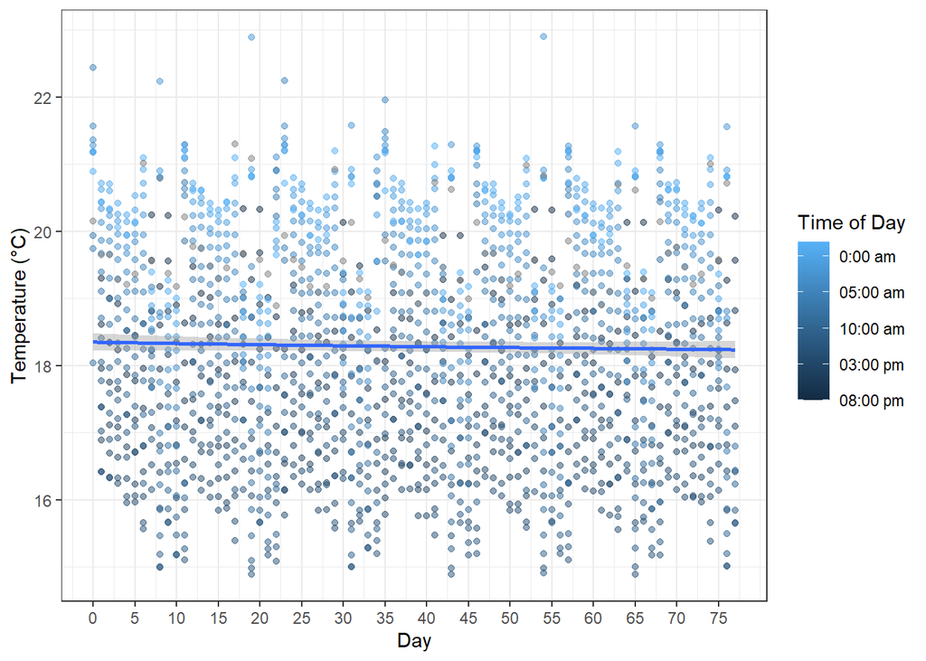

```r
# 14019.26 lux

# temperature plot
# add a small amount of random noise to the y-values
colonisation_temp_light $ temperature_colonisation <- jitter(colonisation_temp_light $ temperature_colonisation)

t2 <- ggplot(
  data = colonisation_temp_light,
  mapping = aes( x = day, y = temperature_colonisation, color = time_of_day)) +
  geom_point(alpha = 0.5) +  # Individual measurements with transparency
  geom_smooth() +
  labs(
    x = "Day", y = "Temperature (°C)"
  ) +
  theme_bw() +
  scale_x_continuous(breaks = seq(0, 77, by = 5)) +
  scale_color_continuous(
    name = "Time of Day",
    breaks = c(0, 5, 10, 15, 20),
    labels = c("08:00 pm", "03:00 pm", "10:00 am", "05:00 am", "0:00 am"),
    limits = c(0, 22),
  )

t2
```

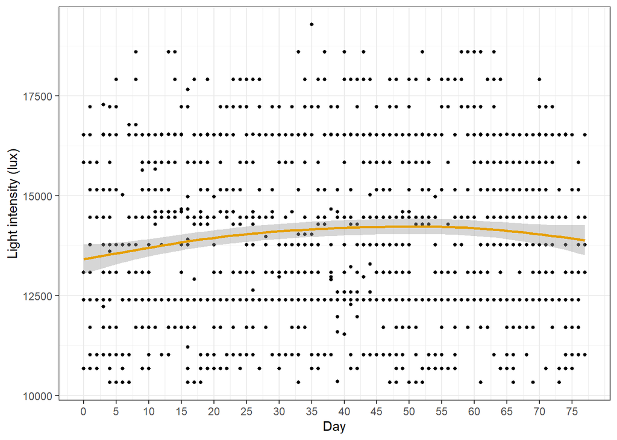

```r
# save the plot
ggsave(
  "output/temperature_colonisation.png",
  width = 16.5,
  height = 12,
  units = "cm",
  dpi = 600
)
# light intensity plot
# Filter the data to include only rows where light_intensity > 0
filtered_data2 <- colonisation_temp_light %>%
  filter(light_intensity_colonisation > 0)

# add a small amount of random noise to the y-values
filtered_data2 $ light_intensity_colonisation <- jitter(filtered_data2 $ light_intensity_colonisation)

l2 <- ggplot(
  data = filtered_data2,
  mapping = aes( x = day, y = light_intensity_colonisation)) +
  geom_point(size = 1) +  # Individual measurements with transparency
  geom_smooth(color = "#E69F00", linewidth = 1) +
  labs(
    x = "Day", y = "Light intensity (lux)"
  ) +
  theme_bw() +
  scale_x_continuous(breaks = seq(0, 77, by = 5))

l2
```

```r
# save the plot
ggsave(
  "output/light_intensity_colonisation.png",
  width = 16.5,
  height = 12,
  units = "cm",
  dpi = 600
)
```

## 8.2 Feeding assay

```r
# insert data
feeding_assay_temp_light <-
  read.table(file.path("data\\feeding_assay_temp_light.txt"),
             header = TRUE,
             sep = "\t"
  )

View(feeding_assay_temp_light)

# average temperature
mean(feeding_assay_temp_light $ temperature)
```

```
[1] 13.27927
```

```r
# 13.27927 °C

# mean light intensity
# filter only daytime
average_light_intensity_feeding <- feeding_assay_temp_light %>%
  dplyr::filter(light_intensity > 0) %>%
  dplyr::summarize(average_light_intensity_feeding = mean(light_intensity))

print(average_light_intensity_feeding)
```

```
  average_light_intensity_feeding
1                        330.3552
```

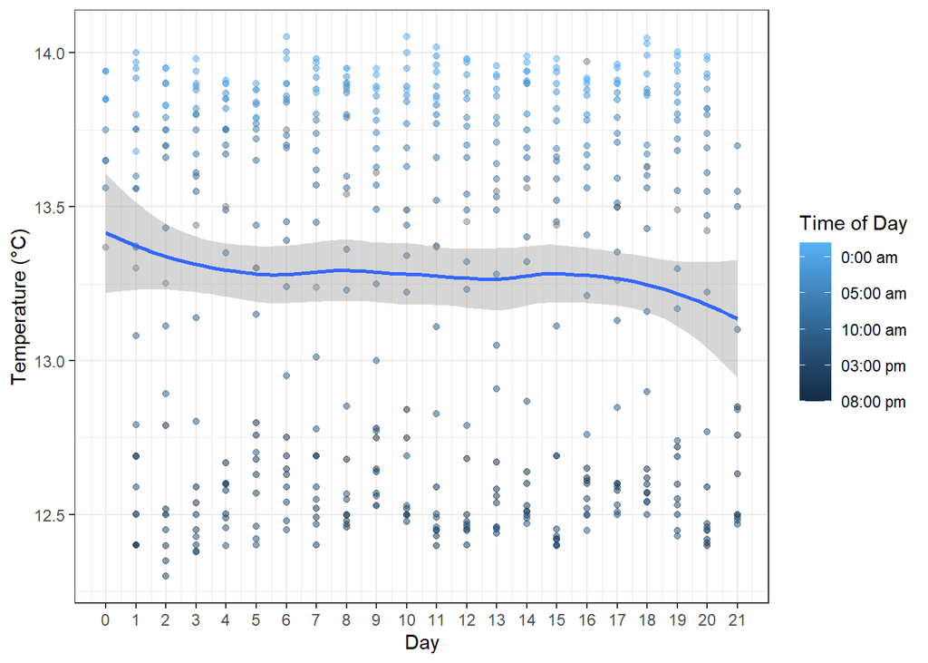

```r
# 330.3552 lux

# temperature plot
# add a small amount of random noise to the y-values
feeding_assay_temp_light $ temperature <- jitter(feeding_assay_temp_light $ temperature)

t1 <- ggplot(
  data = feeding_assay_temp_light,
  mapping = aes( x = day, y = temperature, color = time_of_day)) +
  geom_point(alpha = 0.5) +  # Individual measurements with transparency
  geom_smooth() +
  labs(
    x = "Day", y = "Temperature (°C)"
  ) +
  theme_bw() +
  scale_x_continuous(breaks = 0:21) +
  scale_color_continuous(
    name = "Time of Day",
    breaks = c(0, 5, 10, 15, 20),
    labels = c("08:00 pm", "03:00 pm", "10:00 am", "05:00 am", "0:00 am"),
    limits = c(0, 22),
  )

t1
```

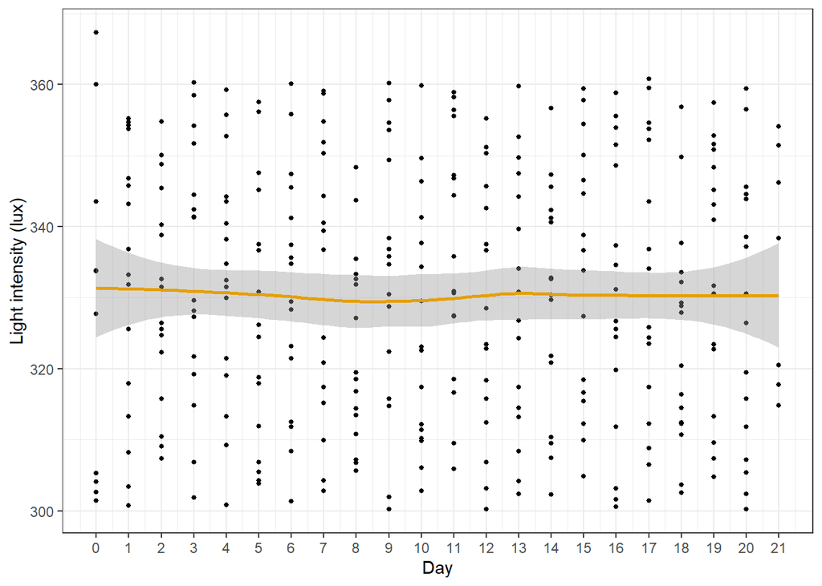

```r
# save the plot
ggsave(
  "output/temperature_feeding_assay.png",
  width = 16.5,
  height = 12,
  units = "cm",
  dpi = 600
)
# light intensity plot
# Filter the data to include only rows where light_intensity > 0
filtered_data1 <- feeding_assay_temp_light %>%
  filter(light_intensity > 0)

# add a small amount of random noise to the y-values
filtered_data1 $ light_intensity <- jitter(filtered_data1 $ light_intensity)

l1 <- ggplot(
  data = filtered_data1,
  mapping = aes( x = day, y = light_intensity)) +
  geom_point(size = 1) +  # Individual measurements with transparency
  geom_smooth(color = "#E69F00", linewidth = 1) +
  labs(
    x = "Day", y = "Light intensity (lux)"
  ) +
  theme_bw() +
  scale_x_continuous(breaks = 0:21)

l1
```

```r
# save the plot
ggsave(
  "output/light_intensity_feeding_assay.png",
  width = 16.5,
  height = 12,
  units = "cm",
  dpi = 600
)
```

# 9 Chemical analyses

```r
# insert data
chemical_analyses <-
  read.table(file.path("data\\chemical_analyses.txt"),
             header = TRUE, sep = "\t")

View(chemical_analyses)

# LOQ to NA
chemical_analyses[chemical_analyses == "<LOQ"] <- NA
# concentration values as numeric
chemical_analyses$concentration_ug_L <- as.numeric(
  ifelse(chemical_analyses$concentration_ug_L == "<LOQ", NA, chemical_analyses$concentration_ug_L)
)

# calculate means, se, 95% CI
chemical_means <- chemical_analyses %>%
  filter(!is.na(concentration_ug_L)) %>%
  dplyr::mutate(percent_deviation = 100 * (concentration_ug_L - nominal_conc) / nominal_conc) %>%
  dplyr::group_by(treatment, mixture) %>%
  dplyr::summarize(
    mean_concentration = mean(concentration_ug_L, na.rm = TRUE),
    n = sum(!is.na(concentration_ug_L)),
    se = sd(concentration_ug_L, na.rm = TRUE) / sqrt(n),
    t_crit = qt(0.975, df = n - 1),
    ci_lower = mean_concentration - t_crit * se,
    ci_upper = mean_concentration + t_crit * se,
    mean_percent_deviation = mean(percent_deviation, na.rm = TRUE),
    se_percent_deviation = sd(percent_deviation, na.rm = TRUE) / sqrt(sum(!is.na(percent_deviation))),
    .groups = "drop"
  ) %>%
  dplyr::select(treatment, mixture, mean_concentration, ci_lower, ci_upper, se, mean_percent_deviation, se_percent_deviation)

print(chemical_means)
```

```
# A tibble: 6 × 8
  treatment                 mixture mean_concentration ci_lower ci_upper      se
  <chr>                     <chr>                <dbl>    <dbl>    <dbl>   <dbl>
1 ciprofloxacin             no                   73.7     39.0    108.   1.25e+1
2 ciprofloxacin             yes                  56.6     46.4     66.7  3.18e+0
3 propyzamide               no                    6.85     5.92     7.78 3.36e-1
4 propyzamide               yes                   6.80     5.80     7.79 3.12e-1
5 stock_solution_ciproflox… no                61770.   49710.   73831.   2.80e+3
6 stock_solution_propyzami… no                 6521.    4867.    8175.   3.84e+2
# ℹ 2 more variables: mean_percent_deviation <dbl>, se_percent_deviation <dbl>
```